# Prediction of Physical Exercise Method

Kevin Wagg

January 6, 2018

## Synopsis

The goal of this analysis is to create a prediction model that determines the manner in which a subject is doing an exercise. Six subjects performed a variety of exercises under the supervision of a trainer. The subjects wore a variety of measurement devices (accelerometers and gyros) that recorded their movements. These measurements constitute the data being analyzed. With the guidance of the trainer the subjects performed each exercise in one of five ways. The five methods are identified in the field “classe” by the letters A through E. We will attempt to create a model that accurately predicts exercise type.

Once a model has been selected it will be used to generate predictions for twenty test cases provided as part of the Prediction Assignment of the Coursera Practical Machine Learning course from Johns Hopkins University.

## Data Cleaning

Test data and training data was provied in the files pml-training.csv and pml-testing.csv from the link https://d396qusza40orc.cloudfront.net/predmachlearn. Please see the footnote at the bottom of this report for a full description of the source.

Examination of the data indicates that a several columns will be of no use in predicting the outcomes from the test data provided. Specifically, any columns containing the same value for every record in the test set have been removed from both sets. For example, the “new_window” column had a value of “no” for every record in the test set and therefore will have no predictive value. Many columns contained mostly NA values and were therefore removed.

```r
library(caret)
```

```r
library(ggplot2)

set.seed(1966)

origData <- read.csv('C:/Users/kevin/Documents/GitHub/MachineLearning/WeightTraining/pml-training.csv')

sourceData <- cbind(origData[,2], origData[,8:11], origData[,37:49], origData[,60:68], origData[,84:86], origData[,102], origData[,113:124], origData[,140], origData[,151:160])

# Names of single extracted columns need to be fixed
names(sourceData)[1] <- "user_name"
names(sourceData)[31] <- "total_accel_dumbbell"
names(sourceData)[44] <- "total_accel_forearm"
```

## Data Preprocessing

In an attempt to increase the accuracy of the predictions the training data was first normalized. Subsequent analysis showed that this had an insignificant effect on the results, increasing the accuracy of the best model on the test data by only 0.03%. (The effect was larger on poorer performing models.)

The possibility of improving results by removing or combining highly correlated covariates was also examined. Using the cor() function we identified the list of covariates with a correlation higher than 90%.

```r
# Create preprocess parameters from the original data
preprocessParams  <- preProcess(sourceData, method=c("center", "scale"))

sourceData$sampleSet <- sample(1:6, nrow(sourceData), replace = TRUE)

# Normalize the data to give each accelerometer equal weight
transformed <- predict(preprocessParams, sourceData)

# Test the corelation in the provided data
myCor <- abs(cor(transformed[,2:17])) > 0.9
myCor <- data.frame(myCor)

for(i in 1:nrow(myCor)){
    for(j in 1:ncol(myCor)){
        if(myCor[i,j] == TRUE){
            if (row.names(myCor)[i] != names(myCor)[j]){
                print(paste(row.names(myCor)[i], names(myCor)[j], format(cor(transformed[,row.names(myCor)[i]], transformed[,names(myCor)[j]]), digits = 2, nsmall = 2), sep = " "))
            }
        }
    }
}
```

```
## [1] "roll_belt total_accel_belt 0.98"
## [1] "roll_belt accel_belt_y 0.92"
## [1] "roll_belt accel_belt_z -0.99"
## [1] "pitch_belt accel_belt_x -0.97"
## [1] "total_accel_belt roll_belt 0.98"
## [1] "total_accel_belt accel_belt_y 0.93"
## [1] "total_accel_belt accel_belt_z -0.97"
## [1] "accel_belt_x pitch_belt -0.97"
## [1] "accel_belt_y roll_belt 0.92"
## [1] "accel_belt_y total_accel_belt 0.93"
## [1] "accel_belt_y accel_belt_z -0.93"
## [1] "accel_belt_z roll_belt -0.99"
## [1] "accel_belt_z total_accel_belt -0.97"
## [1] "accel_belt_z accel_belt_y -0.93"
```

The plot below shows an example of two of the highly correlated normalized covariates: roll_belt and accel_belt. It wasn’t practical to view all corellated values, the table of values above was sufficient for identifying covariates that might be removed or summed or weighted.

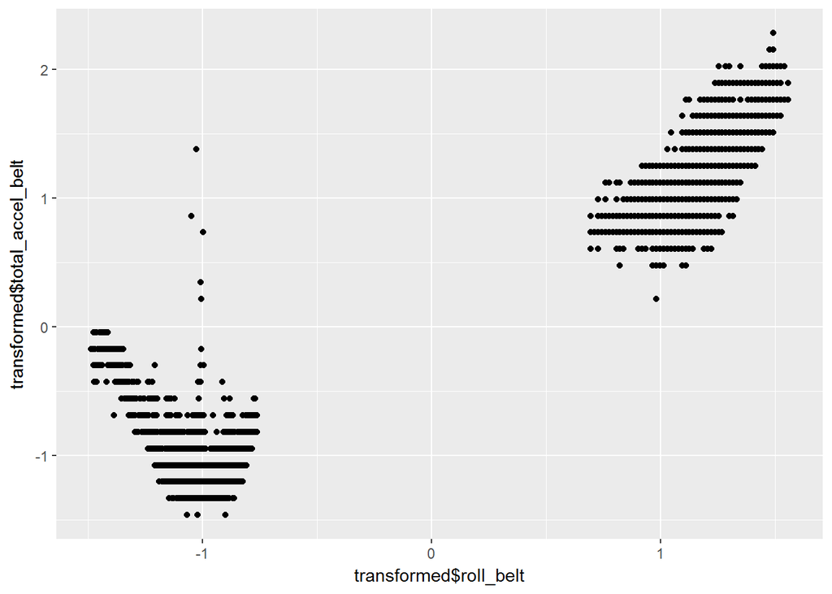

```r
qplot(transformed$roll_belt, transformed$total_accel_belt)
```

In an attempt to improve the model the roll_belt and total_accel_belt covariates were summed and the model was regenerated. This had no effect on the prediction accuracy using the test set.

The complete removal of the accel_belt_x, accel_belt_y and accel_belt_z covariates was also tested since they were highly correlated with other covariates. This also had no effect on the prediction accuracy using the test set.

## Create Training, Test and Validation Data Sets

Once the above transformations were complete the original training data set was divided into separate training, test and validation sets. The test and validation sets each represented approximately one sixth of the original data set selected at random. The remaining data became the training set used to find the optimum model.

```r
# Create training, test and validation data sets
fTrain <- transformed[transformed$sampleSet < 5,]
fTest <- transformed[transformed$sampleSet == 5,]
fValidation <- transformed[transformed$sampleSet == 6,]
```

## Model Generation and Testing

A total of five different models were tested. For every model cross validation was done as part of the train method by implementing the trControl option. The code for creating each model is below. (Only the Bagged CART code is uncommented below since it was easily the best model. Each can be tested by removing the comment and then executing the “predict”" and “confusionMatrix”" commands that follow.)

```r
mod <- train(classe ~ . -sampleSet, data = fTrain, method = "treebag", trControl = trainControl(method = "cv", number = 5))
#mod <- train(classe ~ . -sampleSet, data = fTrain, method = "pls", trControl = trainControl(method = "cv", number = 5))
#mod <- train(classe ~ . -sampleSet, data = fTrain, method = "rpart", trControl = trainControl(method = "cv", number = 5))
#mod <- train(classe ~ . -sampleSet, data = fTrain, method = "amdai", trControl = trainControl(method = "cv", number = 5))
#mod <- train(classe ~ . -sampleSet, data = fTrain, method = "ctree", trControl = trainControl(method = "cv", number = 5))

results <- predict(mod, fTest)
confusionMatrix(results, fTest$classe)
```

```
## Confusion Matrix and Statistics
##
##           Reference
## Prediction   A   B   C   D   E
##          A 965  11   0   3   0
##          B   2 595   7   1   4
##          C   3   8 557   6   1
##          D   1   1   2 521   2
##          E   1   3   2   0 595
##
## Overall Statistics
##
##                Accuracy : 0.9824
##                  95% CI : (0.9773, 0.9866)
##     No Information Rate : 0.2954
##     P-Value [Acc > NIR] : <2e-16
##
##                   Kappa : 0.9776
##  Mcnemar's Test P-Value : 0.1063
##
## Statistics by Class:
##
##                      Class: A Class: B Class: C Class: D Class: E
## Sensitivity            0.9928   0.9628   0.9806   0.9812   0.9884
## Specificity            0.9940   0.9948   0.9934   0.9978   0.9978
## Pos Pred Value         0.9857   0.9770   0.9687   0.9886   0.9900
## Neg Pred Value         0.9970   0.9914   0.9959   0.9964   0.9974
## Prevalence             0.2954   0.1878   0.1726   0.1613   0.1829
## Detection Rate         0.2932   0.1808   0.1692   0.1583   0.1808
## Detection Prevalence   0.2975   0.1851   0.1747   0.1601   0.1826
## Balanced Accuracy      0.9934   0.9788   0.9870   0.9895   0.9931
```

The output of the confusionMatrix command indicates that the Bagged CART model predicts the exercise type with over 98% accuracy. The other models weren’t as accurate. They performed as follows:

Partial Least Squares (“pls”): Accuracy: 39.02% CART (“rpart”“): 49.92% Adaptive Mixture Discriminent Analysis (”amdai“): 73.5% ctree: 88.82%

## Validation

Having now selected the Bagged CART model as the most accurate, it will be tested once against the validation data set.

```r
results <- predict(mod, fValidation)
confusionMatrix(results, fValidation$classe)
```

```
## Confusion Matrix and Statistics
##
##           Reference
## Prediction   A   B   C   D   E
##          A 921   7   0   2   0
##          B   3 602   4   1   2
##          C   1   4 555   7   3
##          D   0   3   1 509   2
##          E   3   3   0   0 628
##
## Overall Statistics
##
##                Accuracy : 0.9859
##                  95% CI : (0.9812, 0.9897)
##     No Information Rate : 0.2846
##     P-Value [Acc > NIR] : < 2e-16
##
##                   Kappa : 0.9821
##  Mcnemar's Test P-Value : 0.05011
##
## Statistics by Class:
##
##                      Class: A Class: B Class: C Class: D Class: E
## Sensitivity            0.9925   0.9725   0.9911   0.9807   0.9890
## Specificity            0.9961   0.9962   0.9944   0.9978   0.9977
## Pos Pred Value         0.9903   0.9837   0.9737   0.9883   0.9905
## Neg Pred Value         0.9970   0.9936   0.9981   0.9964   0.9973
## Prevalence             0.2846   0.1898   0.1717   0.1592   0.1947
## Detection Rate         0.2824   0.1846   0.1702   0.1561   0.1926
## Detection Prevalence   0.2852   0.1877   0.1748   0.1579   0.1944
## Balanced Accuracy      0.9943   0.9844   0.9928   0.9893   0.9933
```

The model provides 98% prediction accuracy using the validation data. We can proceed with confidence to predict the outcomes of the exercise data. The predictions are below.

```r
exerciseData <- read.csv('C:/Users/kevin/Documents/GitHub/MachineLearning/WeightTraining/pml-testing.csv')

procData <- cbind(exerciseData[,2], exerciseData[,8:11], exerciseData[,37:49], exerciseData[,60:68], exerciseData[,84:86], exerciseData[,102], exerciseData[,113:124], exerciseData[,140], exerciseData[,151:159])

# Names of single extracted columns need to be fixed
names(procData)[1] <- "user_name"
names(procData)[31] <- "total_accel_dumbbell"
names(procData)[44] <- "total_accel_forearm"

procData$classe <- "X"
procData$sampleSet <- 0

transEx <- predict(preprocessParams, procData)

results <- predict(mod, transEx)
results
```

```
##  [1] B A B A A E D D A A B C B A E E A B B B
## Levels: A B C D E
```

## Conclusion

The Bagged CART model performed best yielding a 98% accuracy predicting which type of exercise was being done.

## Footnote

Data for this analysis was provided by: Ugulino, W.; Cardador, D.; Vega, K.; Velloso, E.; Milidiu, R.; Fuks, H. Wearable Computing: Accelerometers’ Data Classification of Body Postures and Movements. Proceedings of 21st Brazilian Symposium on Artificial Intelligence. Advances in Artificial Intelligence - SBIA 2012. In: Lecture Notes in Computer Science. , pp. 52-61. Curitiba, PR: Springer Berlin / Heidelberg, 2012. ISBN 978-3-642-34458-9. DOI: 10.1007/978-3-642-34459-6_6.

The data was made available here: http://web.archive.org/web/20161224072740/http:/groupware.les.inf.puc-rio.br/har